# NAM

Elio

10/27/2022

The Northern Annular Mode is the leading EOF of NH circulation. Here, shown as the leading EOF of monthly geopotential height anomalies between 1979 and 2000 at 1000 hPa, following the [CPC methodology](https://www.cpc.ncep.noaa.gov/products/precip/CWlink/daily_ao_index/ao.loading.shtml).

Figure 1: Leading EOF of monthly geopotential anomalies north of 20º at each level.

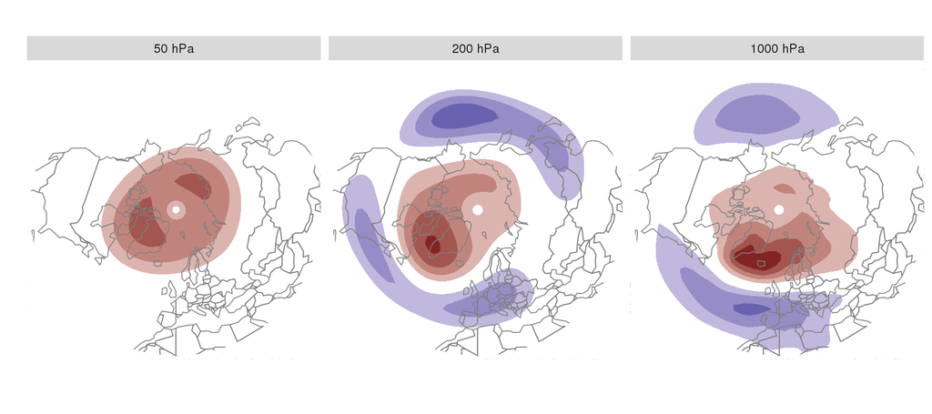

The leading EOF at 1000 hPa is not really all that “annular”. It’s actually a positive anomaly over the Arctic and two negative anomalies over the northern Atlantic and Northern Pacific (or vice versa depending on the sign). Leading EOFs at higher levels do become more annular.

The question is, are the higher latitude anomalies co-occurring? In other words, is this an hemispheric pattern or is it two relatively independent patterns –the Atlantic and Pacific anomalies– that are mixed into a single EOF?

To look into this question I compute the leading EOF of these same data, but using overlapping 90º segments centred at each longitude. This results into 144 local EOFS, one at each longitude. If the NAM is an hemispheric phenomena, then all these indices should be fairly well correlated with each other. On the other hand, if it is a mix of different local modes, then we would expect to see a lack of correlation between separated longitudes.

The next figure shows the result of plotting the central part of each local EOF. The result fits the NAM pattern really well.

Figure 2: Leading EOF computed at 90º chunks centred at each longitude (shaded) and leading EOF computed using the whole domain (contours).

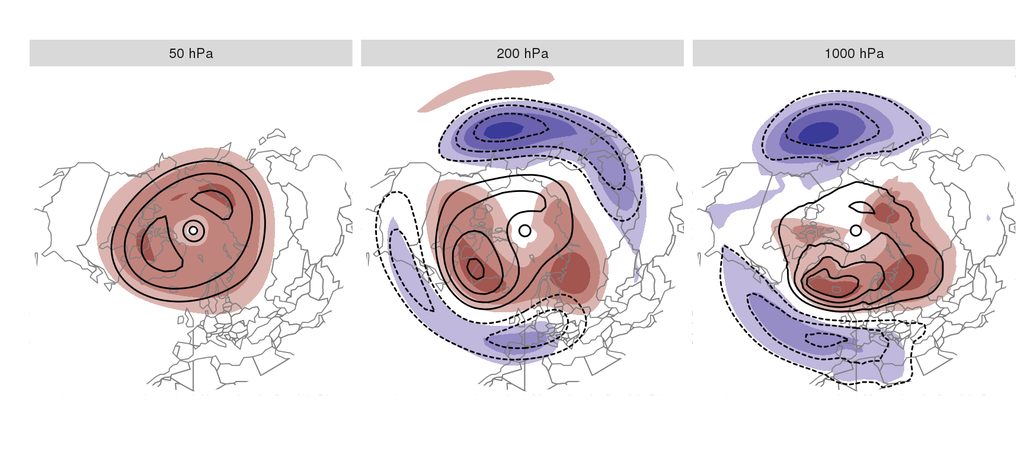

Now, I compute the cross-correlation between all pairs of indices, which is shown in the next figure.

Figure 3: Cross-correlation between the time series of each local EOF. The boxes in the third panel group longitudes into coherent sections based on hierarchical clustering. Background map of the Northern Hemisphere for reference.

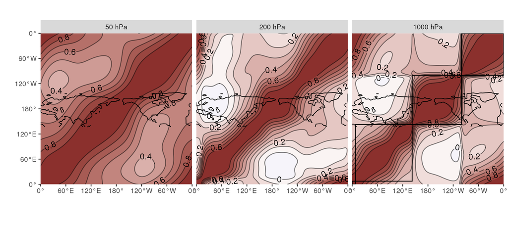

At 1000 hPa there are two (or three) clearly delineated regions that have high intra-correlation but low inter-correlation

So, for example, local EOFS in the Pacific sector share correlations above 0.8 among themselves, but low (0.2–0.3) correlations with EOFs in the Atlantic sector and no correlation (< 0.2) with EOFs in the Eurasian sector.

This strongly suggest that there are there relatively independent modes of variability instead of a single hemispheric mode. EOFs in the Eurasian sector are not as highly correlated among themselves as the other two, so they might not form a single robust area of joint variability.

Higher levels are not as clustered.

Local EOFs at 200 hPa show some vestigial elements of the correlation structure at 1000 hPa but is not as clear. What it is clearer is the lack of correlation between the Pacific and Eurasian sectors.

Local EOFs at 50 hPa seem to be well correlated along the whole hemisphere. The minimum correlation is between North America and European local EOFs, but even those are a very respectable 0.4. This suggests a more robust hemispheric mode.

This regionalisation of the local EOFs at 1000 hPa is broadly applicable to all trimesters, as shown in the next figure.

Figure 4: Same as the previous figure but by trimester and only for 1000 hPA.

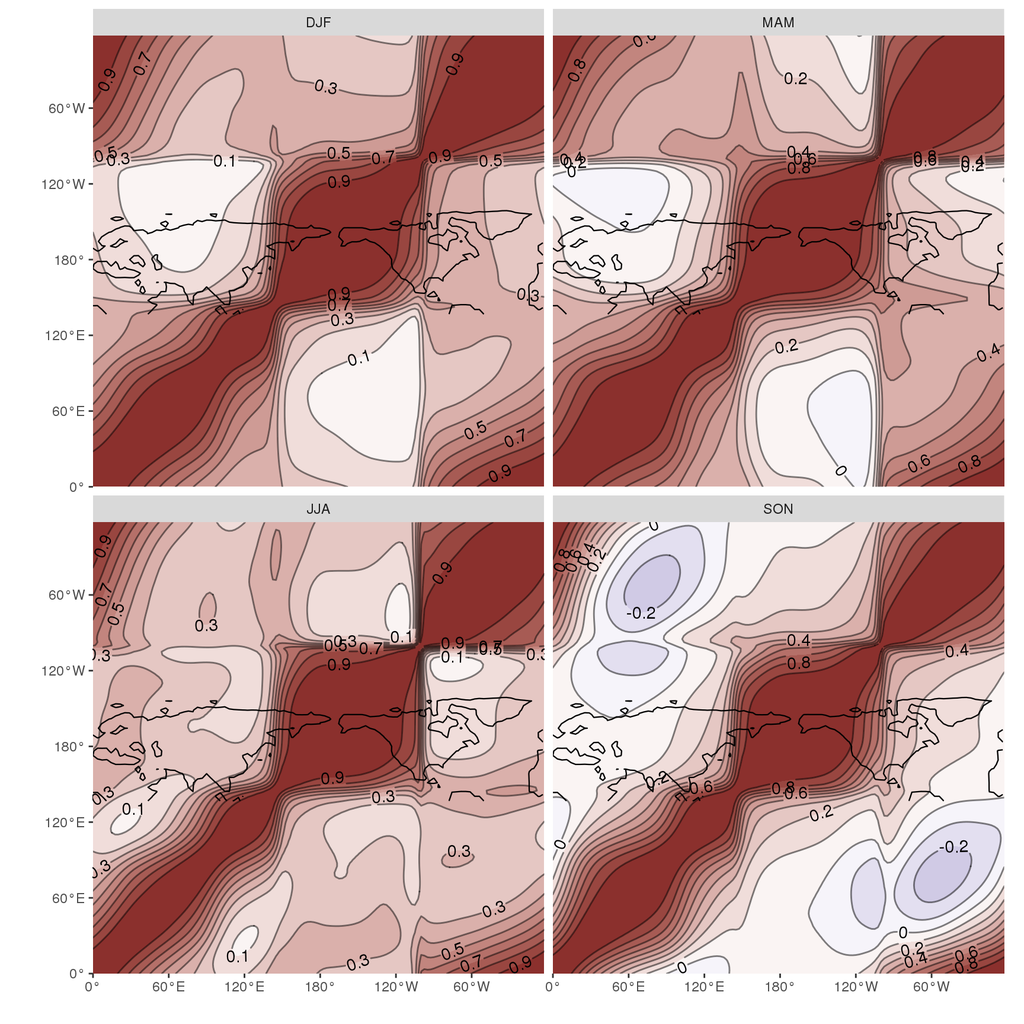

The next figure shows the correlation between geopotential height anomalies at 1000 hPa and these regional EOFs defined as the mean index of the local EOFs belonging to that region.

Figure 5: Correlation between 1000 hPa geopotential height and the regional EOF index computed as the mean indices of local EOFs belonging to that region (shaded) and NAM (contours).

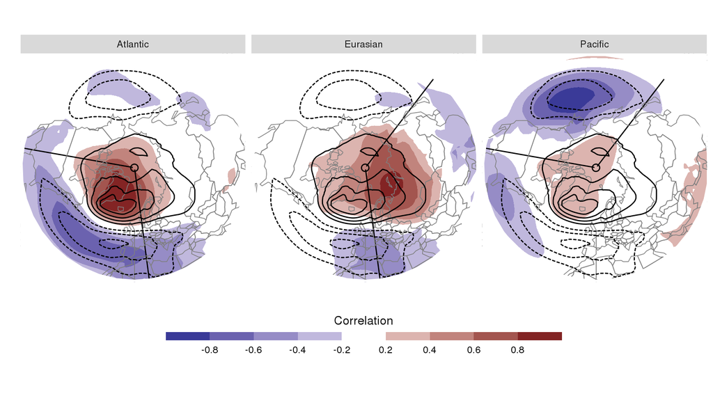

Each regional EOFs is associated with geopotential anomalies only in their respective regions and there is little to no correlation outside each region. Interestingly, each seem to map relatively well to the corresponding features of the NAM pattern, shown in contours.

The Atlantic EOF shows negative anomalies in the northern Atlantic and positive anomalies in the polar regions, which are co-located with the corresponding NAM anomalies. Notably, it is **not** associated with significant anomalies in the northern Pacific. The polar anomalies do not extent so much to the south in the Eurasian sector.

This further suggest the independent nature of these three (or two) different modes of variability that are mixed in the NAM.

Figure 6: Correlation between each local EOF and the Oceanic Niño Index (ONI). The horizontal dashed line marks the correlation between the NAM and the ONI.

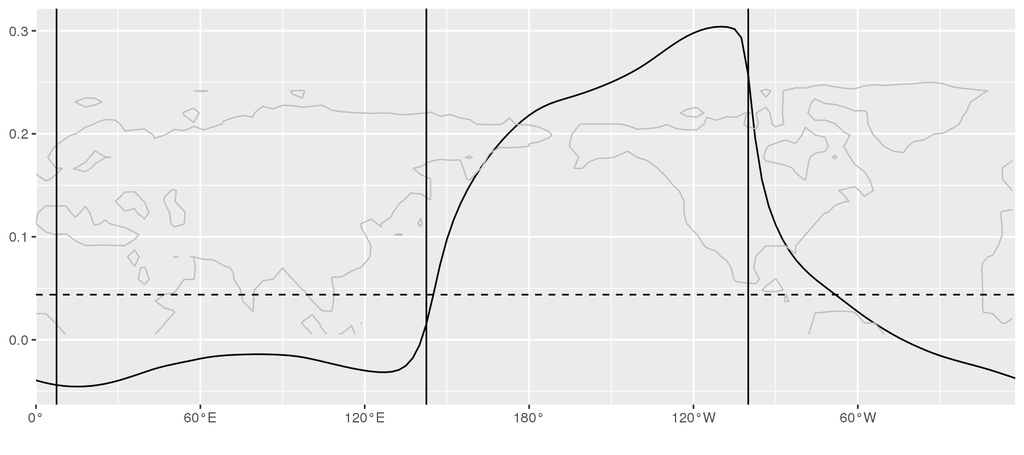